# Blog

# 1. Grid

Start by converting the data from data.frame to an sf object using functions from the package **sf**

```r
library(sf)
```

Using the argument **st_as_sf** convert the data to a sf object

```r
my_points<-my_data %>%
  st_as_sf(coords=c('Longitude','Latitude'),
           crs=4326,
           remove=FALSE)
```

For plotting the data use the package **ggplot2**

```r
library(ggplot2)
```

Since the data is an sf object, use the function **geom_sf** to plot

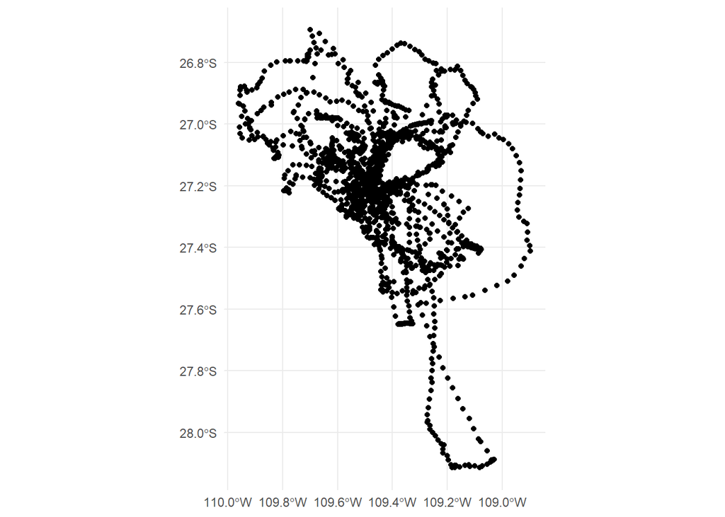

```r
ggplot()+
  geom_sf(data=my_points)+
  theme_minimal()
```

To create a grid using the points.

A common used method is the **fish net**. By definition, the fish net, or square grids, is a good method of covering a surface. The method is called [tessellation](https://en.wikipedia.org/wiki/Tessellation), and it converts a surface with no overlaps or gaps, like when using tiles.

To create a grid the function **st_make_grid** can be used

The arguments of the function **st_make_grid** are:  
**n** - an integer of length 1 or 2, which corresponds to the number of grid cells in x and y direction (columns, rows)  
**what** - defines if polygons, corners or centers are to be created  
**square**- is set to TRUE creates squares, if set to FALSE creates an hexagonal grid

To decide on the size of the grids, check the differences in latitudes and longitudes using the function **range**

```r
range(my_points$Latitude)
range(my_points$Longitude)
```

[output not shown]

```r
my_grid<-st_make_grid(my_points,
                       c(0.05, 0.05),
                       what = "polygons",
                       square = TRUE)
```

Now that the grid has been calculated, transform the grid to sf using the function **st_sf** and add an *grid_id* to the grid cell using the function **mutate** from the package **dplyr**

```r
library(dplyr)
```

```r
my_grid_sf = st_sf(my_grid) %>%
  mutate(grid_id = 1:length(lengths(my_grid)))
```

To plot the recently created grid:

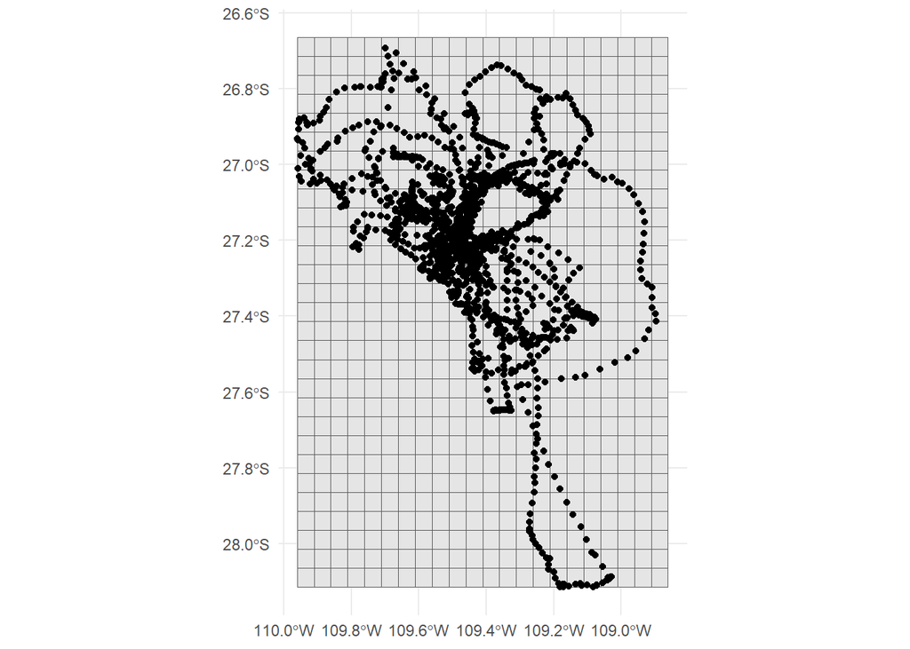

```r
ggplot()+
  geom_sf(data=my_grid_sf)+
  geom_sf(data=my_points)+
  theme_minimal()
```

# 2. Extract values per grid

Using the argument **lenghts** the sample number per grid can be calculated

```r
my_grid_sf$nlocs <- lengths(st_intersects(my_grid_sf,
                                          my_points))
```

To add color to the plot, the package **viridis** provides the function **scale_fill_viridis**.

```r
library(viridis)
```

The color will correspond to the number of locations (nlocs)

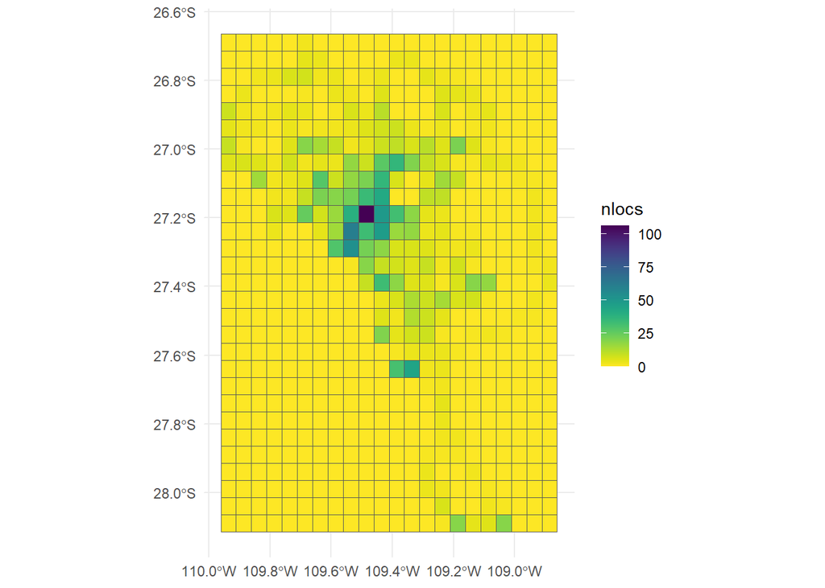

```r
ggplot()+
  geom_sf(data=my_grid_sf,aes(fill=nlocs))+
  theme_minimal()+
  scale_fill_viridis(direction = -1)
```

# 3. Surveyed

To keep only the grid cells that were surveyed, the grid cells that have 0 recording can be removed

```r
grid_w_data = filter(my_grid_sf, nlocs > 0)
```

To check which grid cells were removed, plot the previous and current grid

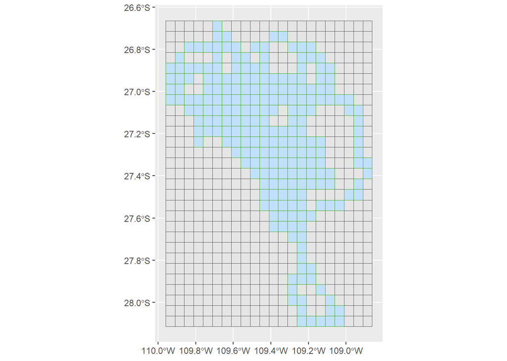

```r
ggplot()+
  geom_sf(data = my_grid)+
  geom_sf(data = grid_w_data, colour = "#42a921", fill= '#bde0fe',alpha=0.9)+
  NULL
```

# 4. Mean values

To calculate the mean values per grid, functions from the package **tidyverse** can be used

```r
my_dens<-my_points
```

For the exercise, generate random data using the function **runif**

```r
my_dens$densities<-runif(nrow(my_dens), min=0, max=1)
```

To transform from data.frame to sf object the function **st_as_sf** can be used

```r
my_dens_sf <-my_dens %>%
  st_as_sf(coords = c("Longitude", "Latitude"))
```

To assign the coordinate system the function **st_set_crs** can be used

```r
my_dens_sf  = st_set_crs(my_dens_sf , "EPSG:4326")
```

Using the function **st_intersection**, the grid number to each data point is added

```r
dens_grid <- st_intersection(grid_w_data,my_dens_sf)
```

With the function **mutate**, the mean density per grid can be calculated

```r
dens_mean <- dens_grid %>%
  st_drop_geometry() %>%
  group_by(grid_id)%>%
  mutate(grid_dens_means=mean(densities))
```

Finally, the mean density can be added to the general grid

```r
grid_w_dens<-merge(grid_w_data,dens_mean, by='grid_id', all=TRUE)
```

There might be more than one value per grid, to have one value per grid the function **summarise_at** can be used.

```r
grid_dens<-grid_w_dens %>%
  group_by(grid_id)%>%
  summarise_at(vars(grid_dens_means),
               list(name = mean)) %>%
  rename(dens_mean=name)
```

To remove grid without values, the function **drop_na** can be used

```r
library(tidyverse)
```

```r
grid_dens<-grid_dens%>%
  drop_na(dens_mean)
```

To check the values that were removed, plot the data.

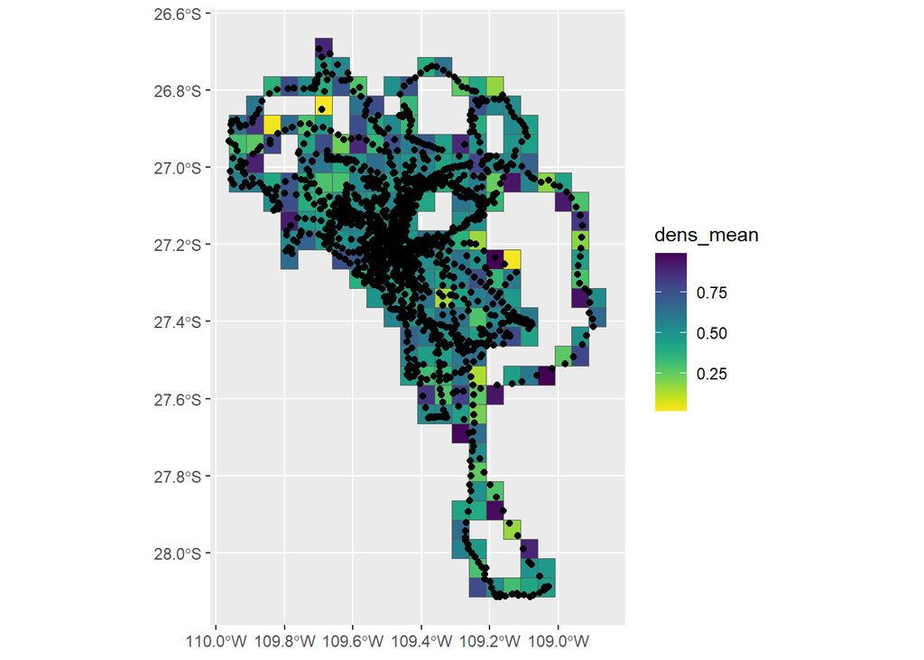

```r
ggplot()+
  geom_sf(data = grid_dens,aes(fill = dens_mean))+
  geom_sf(data= my_dens_sf)+
    scale_fill_viridis(direction = -1)
```

# 5. Customize

The function **geom_sf** allows to plot a raster

Axis labels can be changed using **scale_x_continuous** and **scale_y_continuous**

To see less distracting colors on the background, **theme_minimal** is a prefered option

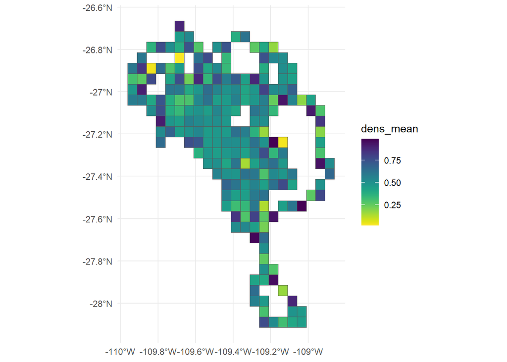

```r
ggplot()+
  geom_sf(data = grid_dens,aes(fill = dens_mean))+
    scale_fill_viridis(direction = -1) +
    scale_x_continuous(labels = function(x) paste0(x, '\u00B0', "W")) +
    scale_y_continuous(labels = function(x) paste0(x, '\u00B0', "N"))+
  theme_minimal()
```

To make a custom raster palette the function **scale_fill_gradientn** can be used

```r
dens_colors<-c('white','#6CB4D3','#1A89AB','#7CC252','#B2EC2B','#DCF754','#FFE454','#FD9708','#F6640F','#EC2C11')
dens_breaks<-c(0,0.30,0.60,0.85)
dens_labels<-c('0','0.30','0.60','> 0.85')
```

The plot with custom palette arguments consider:  
**colours** the number of colors should correspond to the values  
**breaks** for those numbers that are to be displayed  
**labels** for those labels that are to be displayed  
**limits** to set up minimum and maximum values on the scale

To customize legend:  
**legend.key** can be used

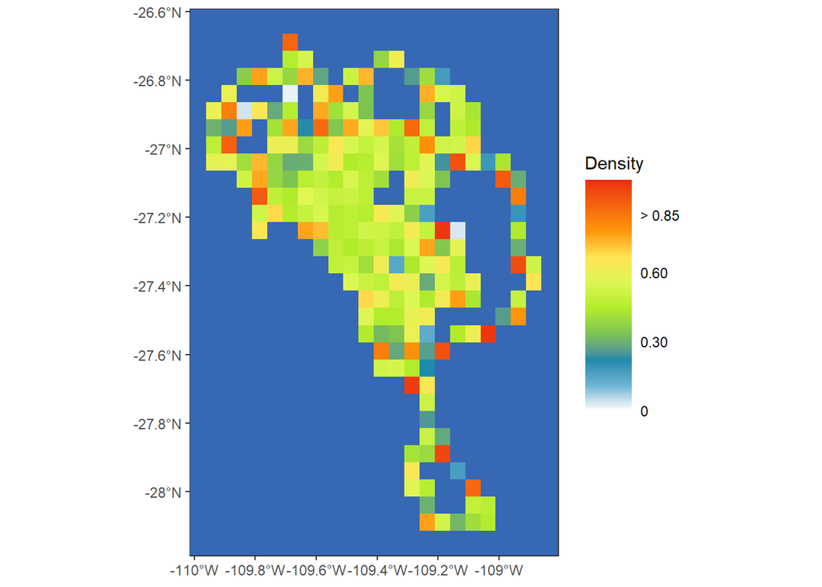

```r
ggplot()+
  geom_sf(data = grid_dens,aes(fill = dens_mean),color='transparent')+

  scale_fill_gradientn(name='Density',
    colours = dens_colors,
    breaks = dens_breaks,
    labels = dens_labels,
    limits=c(0,1))+


    scale_x_continuous(labels = function(x) paste0(x, '\u00B0', "W")) +
    scale_y_continuous(labels = function(x) paste0(x, '\u00B0', "N"))+

  theme_bw()+

  theme(panel.background = element_rect(fill = '#3668b4'),
        panel.grid.major = element_blank(),
        panel.grid.minor = element_blank())+


  theme(
    legend.key = element_rect(color = "black",size=5),
    legend.key.width = unit(1, "cm"),
    legend.key.height = unit(1, "cm")) +

  guides(fill = guide_colorbar(ticks.colour = "transparent"))
```